# Practice7.4_my.t.test

Chia-Jung Tsai

2022-11-04

# My t test (two sample t test)

### First of all, here are some assumptions of t test. Before you use this function, please make sure the observations of your sample obey these rules.

1. Independence: The observations in one sample are independent of the observations in the other sample.
2. Random Sampling: Both samples were obtained using a random sampling method.
3. Normality: Both samples are approximately normally distributed.
4. Homogeneity of Variances: Both samples have approximately the same variance.

Here’s some functions for you to test your data whether it follows the assumption of t test.

### Normality test

To test whether the distribution of your data is drawn from a normally distributed population  
If the test is non-significant (p-value > 0.05)  
=> the distribution of population is a normal distribution. (We use samples to represent population.)

```r
#data <- #put your data here
#shapiro.test(data)
#p-value <- shapiro.test(data)$'p.value'
#p-value
```

### Test homogeneity of variances

Null hypothesis is that all population variances are equal  
If p-values < 0.05  
=> variances are significantly different, that is the homogeneity of variances is not equal

```r
#if data is normality - F test
#var.test <- var.test(value ~ group, data = data) #if p-value > 0.05 => two groups are equal
#var.test$'p.value'

#if data is non-normality - Levene’s test
#levene.test <- car::leveneTest(value ~ group, data = data)
#levene.test$'p.value'

#if variances are not equal (or you have small sample size)
#welch.t.test -> set nor.mal = TRUE, homo.var = FALSE in function my.t.test
```

### Hypothesis of t test (two sample t test)

H0: μx = μy (non-significantly different)  
H1: μx ≠ μy (significantly different)

## My function: t test

α = 0.05

```r
my.t.test <- function(x1, x2, nor.mal = TRUE, homo.var = TRUE){
  if (nor.mal == TRUE & homo.var == TRUE){  #Student's t test
    t <- (mean(x1)-mean(x2))/sqrt((sum((x1 - mean(x1))^2)/(length(x1)-1)) + (sum((x2 - mean(x2))^2)/(length(x2)-1)))
    df <- length(x1) + length(x2) - 2
    t.dtb <- pt(abs(t), df, lower.tail = FALSE, log.p = FALSE) #two tailed t test
    cri.num0.95 <- qt(0.025, df, lower.tail = TRUE, log.p = FALSE) #critical number of conf.Interval at 0.95
    if (abs(t) <= cri.num0.95){
      list(Test = 'Student`s t test',
                 Discription = paste('Discription: two samples are `not` significantly different'),
                 p.value =  paste('p.value =', 2*t.dtb),
                 degree.of.freedom = paste('degree.of.freedom = ', df),
                 confidence.interval = paste('confidence.interval = 95%'))
      }else{
        list(Test = 'Student`s t test',
                   Discription = paste('Discription: two samples are significantly different'),
                   p.value =  paste('p.value =', 2*t.dtb),
                   degree.of.freedom = paste('degree.of.freedom = ', df),
                   confidence.interval = paste('confidence.interval = 95%'))}
  }else if (nor.mal == TRUE & homo.var == FALSE){  # Welch's  t test
    wt <- (mean(x1)-mean(x2))/sqrt(((sd(x1)^2)/length(x1))+((sd(x2)^2)/length(x2)))
    df <- length(x1) + length(x2) - 2
    wt.dtb <- pt(abs(wt), df, lower.tail = FALSE, log.p = FALSE) #two tailed t test
    cri.num0.95 <- qt(0.025, df, lower.tail = TRUE, log.p = FALSE) #critical number of conf.Interval at 0.95
    if (abs(wt) <= cri.num0.95){
      list(Test = 'Welch`s t test',
                 Discription = paste('Discription: two samples are `not` significantly different'),
                 p.value =  paste('p.value =', 2*wt.dtb),
                 degree.of.freedom = paste('degree.of.freedom = ', df),
                 confidence.interval = paste('confidence.interval = 95%'))
    }else{
      list(Test = 'Welch`s t test',
                 Discription = paste('Discription: two samples are significantly different'),
                 p.value =  paste('p.value =', 2*wt.dtb),
                 degree.of.freedom = paste('degree.of.freedom = ', df),
                 confidence.interval = paste('confidence.interval = 95%'))}
  }else{
    print('Your data did not follow normal distribution. Suggestion for you: wilcox.test() -> non-parametric test')
  }
}
```

## Let’s carry out the function with your data

### Dataset: rairuoho

```r
#read the file
rairuoho <- read.delim(url('https://www.dipintothereef.com/uploads/3/7/3/5/37359245/rairuoho.txt'))
```

### Draw a boxplot to visualize the data of rairuoho

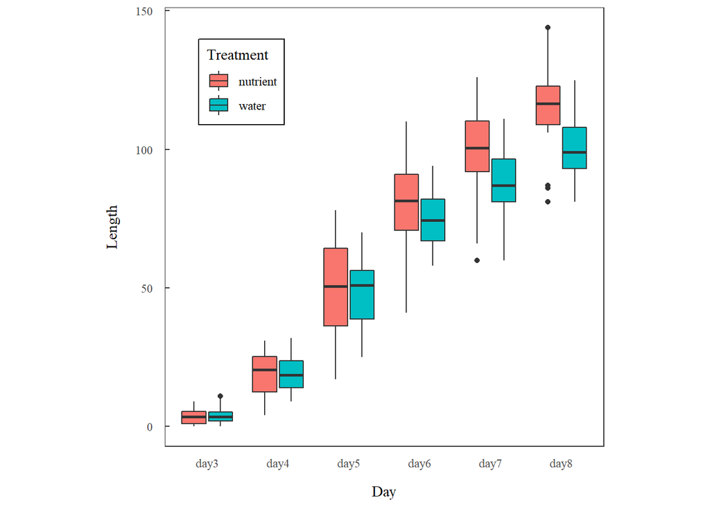

```r
library(ggplot2)
#plot theme written by someone
theme_USGS_box <- function(base_family = "serif", ...){
  theme_bw(base_family = base_family, ...) +
    theme(
      panel.grid = element_blank(),
      plot.title = element_text(size = 8),
      axis.ticks.length = unit(-0.05, "in"),
      axis.text.y = element_text(margin=unit(c(0.3,0.3,0.3,0.3), "cm")),
      axis.text.x = element_text(margin=unit(c(0.3,0.3,0.3,0.3), "cm")),
      axis.ticks.x = element_blank(),
      aspect.ratio = 1,
      legend.background = element_rect(color = "black", fill = "white")
    )
}
library(tidyverse)
new.rairuoho <- pivot_longer(rairuoho, names_to = 'day', values_to = 'length', cols = 1:6)
new.rairuoho.plot <- ggplot(new.rairuoho, aes(x = day, y = length, fill = treatment)) +
  geom_boxplot()+
  theme_USGS_box() +
  xlab('Day') +
  ylab('Length') +
  scale_fill_discrete(name = 'Treatment') +
  theme(legend.position = c(0.175, 0.83))
new.rairuoho.plot
```

## Test the effect of treatment on length at various days in the rairuoho dataset by my t test

```r
outcome <- NULL
for (i in 1:6){
  outcome[[i]] <- list(Day = paste('day', i+2),
                       my.t.test = my.t.test(filter(rairuoho, treatment == 'water')[,i],
                                             filter(rairuoho, treatment == 'nutrient')[,i],
                                             homo.var = F)) # I assume that the population data of rairuoho follows normal distribution.
}
outcome
```

```
## [[1]]
## [[1]]$Day
## [1] "day 3"
##
## [[1]]$my.t.test
## [[1]]$my.t.test$Test
## [1] "Welch`s t test"
##
## [[1]]$my.t.test$Discription
## [1] "Discription: two samples are significantly different"
##
## [[1]]$my.t.test$p.value
## [1] "p.value = 0.520612496562886"
##
## [[1]]$my.t.test$degree.of.freedom
## [1] "degree.of.freedom =  46"
##
## [[1]]$my.t.test$confidence.interval
## [1] "confidence.interval = 95%"
##
##
##
## [[2]]
## [[2]]$Day
## [1] "day 4"
##
## [[2]]$my.t.test
## [[2]]$my.t.test$Test
## [1] "Welch`s t test"
##
## [[2]]$my.t.test$Discription
## [1] "Discription: two samples are significantly different"
##
## [[2]]$my.t.test$p.value
## [1] "p.value = 0.969309544155166"
##
## [[2]]$my.t.test$degree.of.freedom
## [1] "degree.of.freedom =  46"
##
## [[2]]$my.t.test$confidence.interval
```

[output cut: 74 more lines]

```
## [[6]]$my.t.test
## [[6]]$my.t.test$Test
## [1] "Welch`s t test"
##
## [[6]]$my.t.test$Discription
## [1] "Discription: two samples are significantly different"
##
## [[6]]$my.t.test$p.value
## [1] "p.value = 0.000119711579470797"
##
## [[6]]$my.t.test$degree.of.freedom
## [1] "degree.of.freedom =  46"
##
## [[6]]$my.t.test$confidence.interval
## [1] "confidence.interval = 95%"
```

## Summary

From the outcome, we can observe that:  
Non-significantly different: Day3, Day4, Day5, Day6  
Significantly different: Day7, Day8  
We can also see this pattern from boxplot.